# Data Analysis Project (P2), NanoDegree program

# Tedros Hagos

In, this project, I will use the titanic data which Contains demographics and passenger information from 891 of the 2224 . As described from the Kaggle website, the titanic sank after it colided with an iceberg on April, 15, 1912 which resulted in the overall death of 1502 out of 2224 passengers and crew. The question on the project for the titanic dataset is "What factors made people more likely to survive?". Based on this broader question, I will try to refine my questions to answer some of these questions:

1. Who were the passengers on the titanic (age, sex, name...)
2. How does class affect, survival of passengers?
3. Is there any survival rate differece between male and female passengers?
4. is survival affected by age ( is there any previlaged age group?)
5. who survived most, single passengers or passengers with family mebers on board?
6. Does paying higher fare meant better survival rate?

```python
# let us import all the libraries that we will use throughout in this project
import pandas as pd
import numpy as np
import matplotlib.pyplot as plt
import seaborn as sns
import pylab as P
%matplotlib inline
from scipy.stats import chi2_contingency
titanic_df = pd.read_csv('titanic_data.csv') # just calling our data fram without need to specify the path directory
titanic_df.head() # To have a quick overview of what our data looks like,
                  # the head() function gives us the first 5 rows of our data, if we want to see a specified # of rows, we have explicitly put it in the bracket.
                  # Naturally, we expect age to be an integer number, but as described on the kaggle webpage and as our data shows, we have
                  # we have some ages with decimal points (estimated ages and infants less than a year)
```

|  | PassengerId | Survived | Pclass | Name | Sex | Age | SibSp | Parch | Ticket | Fare | Cabin | Embarked |
| --- | --- | --- | --- | --- | --- | --- | --- | --- | --- | --- | --- | --- |
| 0 | 1 | 0 | 3 | Braund, Mr. Owen Harris | male | 22.0 | 1 | 0 | A/5 21171 | 7.2500 | NaN | S |
| 1 | 2 | 1 | 1 | Cumings, Mrs. John Bradley (Florence Briggs Th... | female | 38.0 | 1 | 0 | PC 17599 | 71.2833 | C85 | C |
| 2 | 3 | 1 | 3 | Heikkinen, Miss. Laina | female | 26.0 | 0 | 0 | STON/O2. 3101282 | 7.9250 | NaN | S |
| 3 | 4 | 1 | 1 | Futrelle, Mrs. Jacques Heath (Lily May Peel) | female | 35.0 | 1 | 0 | 113803 | 53.1000 | C123 | S |
| 4 | 5 | 0 | 3 | Allen, Mr. William Henry | male | 35.0 | 0 | 0 | 373450 | 8.0500 | NaN | S |

```python
titanic_df.info() # Let's try to see the number of entries in each column and type of data for each column
                  # from the output window depicted below, we can see that there are missing data in some columns
```

```
<class 'pandas.core.frame.DataFrame'>
RangeIndex: 891 entries, 0 to 890
Data columns (total 12 columns):
PassengerId    891 non-null int64
Survived       891 non-null int64
Pclass         891 non-null int64
Name           891 non-null object
Sex            891 non-null object
Age            714 non-null float64
SibSp          891 non-null int64
Parch          891 non-null int64
Ticket         891 non-null object
Fare           891 non-null float64
Cabin          204 non-null object
Embarked       889 non-null object
dtypes: float64(2), int64(5), object(5)
memory usage: 83.6+ KB
```

Let us investigate more to see the number of missing data for each variable.

```python
titanic_df.isnull().sum() # As displayed below, we have 3 columns with missing data.
                          # Cabin and age data have very high number of missings so, I will try to treat them separately.
```

```
PassengerId      0
Survived         0
Pclass           0
Name             0
Sex              0
Age            177
SibSp            0
Parch            0
Ticket           0
Fare             0
Cabin          687
Embarked         2
dtype: int64
```

### Handling Null -values

for the Cabin column, Since it is a string data, it seems difficult to use any statistical formula to estimate what is missing. so I decided to drop the null and only try to display the not null values.

```python
print "Cabin_Missing_Passenger: ", titanic_df["Cabin"].isnull().sum()

not_null_cabin = titanic_df.dropna(subset = ["Cabin"])
print "Total_Passengers_In_Cabin: ", len(titanic_df)
print "Cabin_NonMissing_Passenger: ", len(not_null_cabin)
not_null_cabin.head()
```

```
Cabin_Missing_Passenger:  687
Total_Passengers_In_Cabin:  891
Cabin_NonMissing_Passenger:  204
```

|  | PassengerId | Survived | Pclass | Name | Sex | Age | SibSp | Parch | Ticket | Fare | Cabin | Embarked |
| --- | --- | --- | --- | --- | --- | --- | --- | --- | --- | --- | --- | --- |
| 1 | 2 | 1 | 1 | Cumings, Mrs. John Bradley (Florence Briggs Th... | female | 38.0 | 1 | 0 | PC 17599 | 71.2833 | C85 | C |
| 3 | 4 | 1 | 1 | Futrelle, Mrs. Jacques Heath (Lily May Peel) | female | 35.0 | 1 | 0 | 113803 | 53.1000 | C123 | S |
| 6 | 7 | 0 | 1 | McCarthy, Mr. Timothy J | male | 54.0 | 0 | 0 | 17463 | 51.8625 | E46 | S |
| 10 | 11 | 1 | 3 | Sandstrom, Miss. Marguerite Rut | female | 4.0 | 1 | 1 | PP 9549 | 16.7000 | G6 | S |
| 11 | 12 | 1 | 1 | Bonnell, Miss. Elizabeth | female | 58.0 | 0 | 0 | 113783 | 26.5500 | C103 | S |

Measures of central tendency (mean and mode) are always affected by extreme values. Even though we have numerous missing values for our age, the age bracket varies greatly. I mean age range goes from less than a year upto 80+. So we will use the median age, which is always resistant to extreme values, to estimate the missing age.

```python
titanic_df['Age'].hist()
P.show()
```

[output not shown]

```python
filled_age = np.where(titanic_df["Age"].isnull(), titanic_df["Age"].median(),titanic_df["Age"])
titanic_df["Age"] = filled_age

titanic_df["Age"].describe()
```

```
count    891.000000
mean      29.361582
std       13.019697
min        0.420000
25%       22.000000
50%       28.000000
75%       35.000000
max       80.000000
Name: Age, dtype: float64
```

The above summary for the variable age shows, we dont have null value for age anymore and thus we can continue our analsis to answer our question of age affects survival of passengers

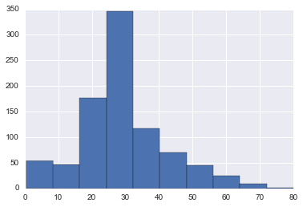

```python
#Let us run the histogram distribution to look what our age looks like
titanic_df['Age'].hist()
P.show()
```

## Exploring our dataset

### Class

```python
# Let's start to answer our first question: Is there any survival rate difference among classes
crosstabulation=pd.crosstab(titanic_df.Survived,titanic_df.Pclass, margins=True)
crosstabulation/crosstabulation.ix["All"]*100
```

| Pclass Survived | 1 | 2 | 3 | All |
| --- | --- | --- | --- | --- |
| 0 | 37.037037 | 52.717391 | 75.763747 | 61.616162 |
| 1 | 62.962963 | 47.282609 | 24.236253 | 38.383838 |
| All | 100.000000 | 100.000000 | 100.000000 | 100.000000 |

The above table shows that, survival rate was different for the 3 different classes, with class 1 having the highest, whereas the 3rd class had the least survival of passengers.

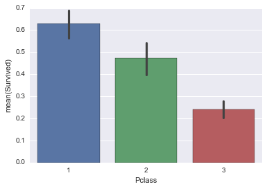

```python
sns.barplot(x="Pclass", y="Survived",data=titanic_df);

# The barplot depicts the percentage of survival in each class.
```

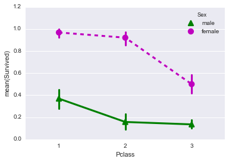

```python
sns.pointplot(x="Pclass", y="Survived", hue="Sex", data=titanic_df,
              palette={"male": "g", "female": "m"},
              markers=["^", "o"], linestyles=["-", "--"]);
```

```python
#crosstabulation
#Let us also try to see if there was survival chance difference across different classes for male and female sepeately.

survival_sex_class = pd.crosstab(index=titanic_df["Survived"],
                             columns=[titanic_df["Pclass"],
                                      titanic_df["Sex"]],
                             margins=True)
survival_sex_class/survival_sex_class.ix["All"]*100
```

| Pclass Sex Survived | 1 female | 1 male | 2 female | 2 male | 3 female | 3 male | All |
| --- | --- | --- | --- | --- | --- | --- | --- |
| 0 | 3.191489 | 63.114754 | 7.894737 | 84.259259 | 50.0 | 86.455331 | 61.616162 |
| 1 | 96.808511 | 36.885246 | 92.105263 | 15.740741 | 50.0 | 13.544669 | 38.383838 |
| All | 100.000000 | 100.000000 | 100.000000 | 100.000000 | 100.0 | 100.000000 | 100.000000 |

Both the above chart and crosstabulation table show that, survival rate difference for the different classes is still there, with the highest survival in class 1 and lowest in class 3. this crosstabulation also suggests females had better survival rate than male across the 3 classes.

### Sex

```python
# Does gender of passengers affect their survival chance?

crosstabulation=pd.crosstab(titanic_df.Survived,titanic_df.Sex, margins=True)
crosstabulation/crosstabulation.ix["All"]*100
```

| Sex Survived | female | male | All |
| --- | --- | --- | --- |
| 0 | 25.796178 | 81.109185 | 61.616162 |
| 1 | 74.203822 | 18.890815 | 38.383838 |
| All | 100.000000 | 100.000000 | 100.000000 |

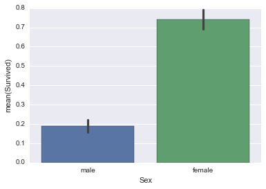

```python
sns.barplot(x="Sex", y="Survived",data=titanic_df)
```

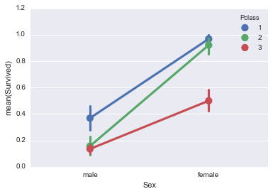

```python
sns.pointplot(x="Sex", y="Survived", hue="Pclass", data=titanic_df);
```

All of the above figures demonstrate female passengers had much higher (74%) survival rate than male passengers(19%).

Let us conduct test-statistic to dig more and find out if there is really survival diffefrence between gender.

Our hypothesis testing will be Ho:Pf=Pm: percentage of the population surivors for both gender is the same H1:Pf > Pm: percentage of the population surivors for both female is greater than male

```python
#to counduct our test-statistic, we use the chi-square contingency
chi2_contingency(pd.crosstab(titanic_df.Survived, titanic_df.Sex))
```

```
(260.71702016732104,
 1.1973570627755645e-58,
 1L,
 array([[ 193.47474747,  355.52525253],
        [ 120.52525253,  221.47474747]]))
```

The chi-square p-value (1.1973570627755645e-58), is alomt 0, which at 95% confidence interval, we reject the null hypothesis and conclude that the percentage of population survived for female is greater male.